[figure not shown]

Prof. Carlos Andrés Ferrero

# Redes Neurais com PyTorch

Análise de Sequências

- Introdução
- Regressão: problema de Bike-sharing prediction
- Atividade

## Introdução

Sequências de dados são muito comuns nos dias atuais e estão presentes em diversas áreas, por ex.

- Dados capturados por acelerômetros de smartphones
- Dados de trajetórias de GPS (*Global Positioning System*)
- Dados de check-ins
- Dados do caminho percorrido dentro de websites por meio dos links
- Dados de exames, por ex., eletrocardiograma, eletroencefalograma, entre outros
- Dados de demanda de produtos e serviços ao longo do tempo
- ...

As tarefas de interesse do ponto de vista de mineração de dados são diversas, por ex.

- Em classificação:
  - Classificar os dados de um exame em normal ou anormal
  - Adivinhar se a partir dos dados de movimentação de um indivíduo é possível estimar quem ele é
  - Classificar clientes pelo seus perfis de movimentação dentro de um site para oferecer novos produtos e serviços
  - ...
- Em regressão:
  - Adivinhar o próximo local em que um taxi vai realizar a sua próxima corrida
  - Estimar quantos produtos ou serviços serão vendidos amanhã ou nos próximos 15 dias
  - ...
- Ainda tem agrupamento (*clustering*, extração de regras ou subsequências relevantes, etc.

## Regressão

- Diferente dos problemas de classificação que nós estudamos até então, as regressões consistem na predição de valores numéricos, ao invés de classes do problema.
- Quando no nosso problema o nosso objetivo é prever um ou mais valores numéricos chamamos a tarefa de regressão.
- Nesta aula vamos aprender a usar redes neurais para predição de dados sequenciais.

### Problema de Bike-Sharing

- Bike-sharing é um conjunto de dados disponível na literatura neste link: https://www.kaggle.com/marklvl/bike-sharing-dataset
- Este dataset contem dados (por hora e por dia) do número de *bikes* que foram alugadas entre 2011 e 2012 em Washington, DC.
- Adicionalmente esses dados foram enriquecidos com dados correspondentes a condições do tempo (Weather Condition) e informações sazonais.
- Acessar o link do conjunto de dados para ver mais detalhes

```python
import pandas as pd
data = 'data/hour.csv'
df = pd.read_csv(data)
display(df)
```

|  | instant | dteday | season | yr | mnth | hr | holiday | weekday | workingday | weathersit | temp | atemp | hum | windspeed | casual | registered | cnt |
| --- | --- | --- | --- | --- | --- | --- | --- | --- | --- | --- | --- | --- | --- | --- | --- | --- | --- |
| 0 | 1 | 2011-01-01 | 1 | 0 | 1 | 0 | 0 | 6 | 0 | 1 | 0.24 | 0.2879 | 0.81 | 0.0000 | 3 | 13 | 16 |
| 1 | 2 | 2011-01-01 | 1 | 0 | 1 | 1 | 0 | 6 | 0 | 1 | 0.22 | 0.2727 | 0.80 | 0.0000 | 8 | 32 | 40 |
| 2 | 3 | 2011-01-01 | 1 | 0 | 1 | 2 | 0 | 6 | 0 | 1 | 0.22 | 0.2727 | 0.80 | 0.0000 | 5 | 27 | 32 |
| 3 | 4 | 2011-01-01 | 1 | 0 | 1 | 3 | 0 | 6 | 0 | 1 | 0.24 | 0.2879 | 0.75 | 0.0000 | 3 | 10 | 13 |
| 4 | 5 | 2011-01-01 | 1 | 0 | 1 | 4 | 0 | 6 | 0 | 1 | 0.24 | 0.2879 | 0.75 | 0.0000 | 0 | 1 | 1 |
| 5 | 6 | 2011-01-01 | 1 | 0 | 1 | 5 | 0 | 6 | 0 | 2 | 0.24 | 0.2576 | 0.75 | 0.0896 | 0 | 1 | 1 |
| 6 | 7 | 2011-01-01 | 1 | 0 | 1 | 6 | 0 | 6 | 0 | 1 | 0.22 | 0.2727 | 0.80 | 0.0000 | 2 | 0 | 2 |
| 7 | 8 | 2011-01-01 | 1 | 0 | 1 | 7 | 0 | 6 | 0 | 1 | 0.20 | 0.2576 | 0.86 | 0.0000 | 1 | 2 | 3 |
| 8 | 9 | 2011-01-01 | 1 | 0 | 1 | 8 | 0 | 6 | 0 | 1 | 0.24 | 0.2879 | 0.75 | 0.0000 | 1 | 7 | 8 |
| 9 | 10 | 2011-01-01 | 1 | 0 | 1 | 9 | 0 | 6 | 0 | 1 | 0.32 | 0.3485 | 0.76 | 0.0000 | 8 | 6 | 14 |
| 10 | 11 | 2011-01-01 | 1 | 0 | 1 | 10 | 0 | 6 | 0 | 1 | 0.38 | 0.3939 | 0.76 | 0.2537 | 12 | 24 | 36 |
| 11 | 12 | 2011-01-01 | 1 | 0 | 1 | 11 | 0 | 6 | 0 | 1 | 0.36 | 0.3333 | 0.81 | 0.2836 | 26 | 30 | 56 |
| 12 | 13 | 2011-01-01 | 1 | 0 | 1 | 12 | 0 | 6 | 0 | 1 | 0.42 | 0.4242 | 0.77 | 0.2836 | 29 | 55 | 84 |
| 13 | 14 | 2011-01-01 | 1 | 0 | 1 | 13 | 0 | 6 | 0 | 2 | 0.46 | 0.4545 | 0.72 | 0.2985 | 47 | 47 | 94 |
| 14 | 15 | 2011-01-01 | 1 | 0 | 1 | 14 | 0 | 6 | 0 | 2 | 0.46 | 0.4545 | 0.72 | 0.2836 | 35 | 71 | 106 |
| 15 | 16 | 2011-01-01 | 1 | 0 | 1 | 15 | 0 | 6 | 0 | 2 | 0.44 | 0.4394 | 0.77 | 0.2985 | 40 | 70 | 110 |
| 16 | 17 | 2011-01-01 | 1 | 0 | 1 | 16 | 0 | 6 | 0 | 2 | 0.42 | 0.4242 | 0.82 | 0.2985 | 41 | 52 | 93 |
| 17 | 18 | 2011-01-01 | 1 | 0 | 1 | 17 | 0 | 6 | 0 | 2 | 0.44 | 0.4394 | 0.82 | 0.2836 | 15 | 52 | 67 |
| 18 | 19 | 2011-01-01 | 1 | 0 | 1 | 18 | 0 | 6 | 0 | 3 | 0.42 | 0.4242 | 0.88 | 0.2537 | 9 | 26 | 35 |
| 19 | 20 | 2011-01-01 | 1 | 0 | 1 | 19 | 0 | 6 | 0 | 3 | 0.42 | 0.4242 | 0.88 | 0.2537 | 6 | 31 | 37 |
| 20 | 21 | 2011-01-01 | 1 | 0 | 1 | 20 | 0 | 6 | 0 | 2 | 0.40 | 0.4091 | 0.87 | 0.2537 | 11 | 25 | 36 |
| 21 | 22 | 2011-01-01 | 1 | 0 | 1 | 21 | 0 | 6 | 0 | 2 | 0.40 | 0.4091 | 0.87 | 0.1940 | 3 | 31 | 34 |
| 22 | 23 | 2011-01-01 | 1 | 0 | 1 | 22 | 0 | 6 | 0 | 2 | 0.40 | 0.4091 | 0.94 | 0.2239 | 11 | 17 | 28 |
| 23 | 24 | 2011-01-01 | 1 | 0 | 1 | 23 | 0 | 6 | 0 | 2 | 0.46 | 0.4545 | 0.88 | 0.2985 | 15 | 24 | 39 |
| 24 | 25 | 2011-01-02 | 1 | 0 | 1 | 0 | 0 | 0 | 0 | 2 | 0.46 | 0.4545 | 0.88 | 0.2985 | 4 | 13 | 17 |
| 25 | 26 | 2011-01-02 | 1 | 0 | 1 | 1 | 0 | 0 | 0 | 2 | 0.44 | 0.4394 | 0.94 | 0.2537 | 1 | 16 | 17 |
| 26 | 27 | 2011-01-02 | 1 | 0 | 1 | 2 | 0 | 0 | 0 | 2 | 0.42 | 0.4242 | 1.00 | 0.2836 | 1 | 8 | 9 |
| 27 | 28 | 2011-01-02 | 1 | 0 | 1 | 3 | 0 | 0 | 0 | 2 | 0.46 | 0.4545 | 0.94 | 0.1940 | 2 | 4 | 6 |
| 28 | 29 | 2011-01-02 | 1 | 0 | 1 | 4 | 0 | 0 | 0 | 2 | 0.46 | 0.4545 | 0.94 | 0.1940 | 2 | 1 | 3 |
| 29 | 30 | 2011-01-02 | 1 | 0 | 1 | 6 | 0 | 0 | 0 | 3 | 0.42 | 0.4242 | 0.77 | 0.2985 | 0 | 2 | 2 |
| ... | ... | ... | ... | ... | ... | ... | ... | ... | ... | ... | ... | ... | ... | ... | ... | ... | ... |
| 17349 | 17350 | 2012-12-30 | 1 | 1 | 12 | 18 | 0 | 0 | 0 | 2 | 0.24 | 0.2121 | 0.44 | 0.2985 | 12 | 113 | 125 |
| 17350 | 17351 | 2012-12-30 | 1 | 1 | 12 | 19 | 0 | 0 | 0 | 1 | 0.34 | 0.3636 | 0.61 | 0.0000 | 16 | 86 | 102 |
| 17351 | 17352 | 2012-12-30 | 1 | 1 | 12 | 20 | 0 | 0 | 0 | 1 | 0.22 | 0.1970 | 0.47 | 0.3284 | 9 | 63 | 72 |
| 17352 | 17353 | 2012-12-30 | 1 | 1 | 12 | 21 | 0 | 0 | 0 | 1 | 0.20 | 0.2121 | 0.51 | 0.1642 | 5 | 42 | 47 |
| 17353 | 17354 | 2012-12-30 | 1 | 1 | 12 | 22 | 0 | 0 | 0 | 1 | 0.20 | 0.1970 | 0.55 | 0.1940 | 6 | 30 | 36 |
| 17354 | 17355 | 2012-12-30 | 1 | 1 | 12 | 23 | 0 | 0 | 0 | 1 | 0.20 | 0.1970 | 0.51 | 0.2239 | 10 | 39 | 49 |
| 17355 | 17356 | 2012-12-31 | 1 | 1 | 12 | 0 | 0 | 1 | 1 | 1 | 0.18 | 0.1818 | 0.55 | 0.1940 | 4 | 30 | 34 |
| 17356 | 17357 | 2012-12-31 | 1 | 1 | 12 | 1 | 0 | 1 | 1 | 1 | 0.18 | 0.1818 | 0.55 | 0.1940 | 6 | 13 | 19 |
| 17357 | 17358 | 2012-12-31 | 1 | 1 | 12 | 2 | 0 | 1 | 1 | 1 | 0.16 | 0.1667 | 0.59 | 0.1642 | 3 | 8 | 11 |
| 17358 | 17359 | 2012-12-31 | 1 | 1 | 12 | 3 | 0 | 1 | 1 | 1 | 0.16 | 0.1818 | 0.59 | 0.1045 | 0 | 1 | 1 |
| 17359 | 17360 | 2012-12-31 | 1 | 1 | 12 | 4 | 0 | 1 | 1 | 1 | 0.14 | 0.1667 | 0.69 | 0.1045 | 0 | 3 | 3 |
| 17360 | 17361 | 2012-12-31 | 1 | 1 | 12 | 5 | 0 | 1 | 1 | 1 | 0.16 | 0.1515 | 0.64 | 0.1940 | 0 | 9 | 9 |
| 17361 | 17362 | 2012-12-31 | 1 | 1 | 12 | 6 | 0 | 1 | 1 | 1 | 0.16 | 0.1667 | 0.64 | 0.1642 | 0 | 40 | 40 |
| 17362 | 17363 | 2012-12-31 | 1 | 1 | 12 | 7 | 0 | 1 | 1 | 1 | 0.16 | 0.1818 | 0.64 | 0.1343 | 2 | 83 | 85 |
| 17363 | 17364 | 2012-12-31 | 1 | 1 | 12 | 8 | 0 | 1 | 1 | 1 | 0.14 | 0.1515 | 0.69 | 0.1343 | 9 | 187 | 196 |
| 17364 | 17365 | 2012-12-31 | 1 | 1 | 12 | 9 | 0 | 1 | 1 | 2 | 0.18 | 0.2121 | 0.64 | 0.1045 | 13 | 144 | 157 |
| 17365 | 17366 | 2012-12-31 | 1 | 1 | 12 | 10 | 0 | 1 | 1 | 2 | 0.20 | 0.2121 | 0.69 | 0.1343 | 33 | 87 | 120 |
| 17366 | 17367 | 2012-12-31 | 1 | 1 | 12 | 11 | 0 | 1 | 1 | 2 | 0.22 | 0.2273 | 0.60 | 0.1940 | 43 | 114 | 157 |
| 17367 | 17368 | 2012-12-31 | 1 | 1 | 12 | 12 | 0 | 1 | 1 | 2 | 0.24 | 0.2273 | 0.56 | 0.1940 | 52 | 172 | 224 |
| 17368 | 17369 | 2012-12-31 | 1 | 1 | 12 | 13 | 0 | 1 | 1 | 2 | 0.26 | 0.2576 | 0.44 | 0.1642 | 38 | 165 | 203 |
| 17369 | 17370 | 2012-12-31 | 1 | 1 | 12 | 14 | 0 | 1 | 1 | 2 | 0.28 | 0.2727 | 0.45 | 0.2239 | 62 | 185 | 247 |
| 17370 | 17371 | 2012-12-31 | 1 | 1 | 12 | 15 | 0 | 1 | 1 | 2 | 0.28 | 0.2879 | 0.45 | 0.1343 | 69 | 246 | 315 |
| 17371 | 17372 | 2012-12-31 | 1 | 1 | 12 | 16 | 0 | 1 | 1 | 2 | 0.26 | 0.2576 | 0.48 | 0.1940 | 30 | 184 | 214 |
| 17372 | 17373 | 2012-12-31 | 1 | 1 | 12 | 17 | 0 | 1 | 1 | 2 | 0.26 | 0.2879 | 0.48 | 0.0896 | 14 | 150 | 164 |
| 17373 | 17374 | 2012-12-31 | 1 | 1 | 12 | 18 | 0 | 1 | 1 | 2 | 0.26 | 0.2727 | 0.48 | 0.1343 | 10 | 112 | 122 |
| 17374 | 17375 | 2012-12-31 | 1 | 1 | 12 | 19 | 0 | 1 | 1 | 2 | 0.26 | 0.2576 | 0.60 | 0.1642 | 11 | 108 | 119 |
| 17375 | 17376 | 2012-12-31 | 1 | 1 | 12 | 20 | 0 | 1 | 1 | 2 | 0.26 | 0.2576 | 0.60 | 0.1642 | 8 | 81 | 89 |
| 17376 | 17377 | 2012-12-31 | 1 | 1 | 12 | 21 | 0 | 1 | 1 | 1 | 0.26 | 0.2576 | 0.60 | 0.1642 | 7 | 83 | 90 |
| 17377 | 17378 | 2012-12-31 | 1 | 1 | 12 | 22 | 0 | 1 | 1 | 1 | 0.26 | 0.2727 | 0.56 | 0.1343 | 13 | 48 | 61 |
| 17378 | 17379 | 2012-12-31 | 1 | 1 | 12 | 23 | 0 | 1 | 1 | 1 | 0.26 | 0.2727 | 0.65 | 0.1343 | 12 | 37 | 49 |

17379 rows × 17 columns

### Visualização dos Dados

Vamos visualizar os dados da variável `registered` que se refere ao número de alugueis de usuários registrados. Esse será o objetivo de predição da nossa aplicação.

Neste gráfico vamos visualizar o primeiro mês de dados (`yr == 0` e `mnth == 1`)

```python
criterion1 = df.yr == 0
criterion2 = df.mnth == 1
criteria = criterion1 & criterion2
df_sel = df[criteria]
df_sel
```

|  | instant | dteday | season | yr | mnth | hr | holiday | weekday | workingday | weathersit | temp | atemp | hum | windspeed | casual | registered | cnt |
| --- | --- | --- | --- | --- | --- | --- | --- | --- | --- | --- | --- | --- | --- | --- | --- | --- | --- |
| 0 | 1 | 2011-01-01 | 1 | 0 | 1 | 0 | 0 | 6 | 0 | 1 | 0.24 | 0.2879 | 0.81 | 0.0000 | 3 | 13 | 16 |
| 1 | 2 | 2011-01-01 | 1 | 0 | 1 | 1 | 0 | 6 | 0 | 1 | 0.22 | 0.2727 | 0.80 | 0.0000 | 8 | 32 | 40 |
| 2 | 3 | 2011-01-01 | 1 | 0 | 1 | 2 | 0 | 6 | 0 | 1 | 0.22 | 0.2727 | 0.80 | 0.0000 | 5 | 27 | 32 |
| 3 | 4 | 2011-01-01 | 1 | 0 | 1 | 3 | 0 | 6 | 0 | 1 | 0.24 | 0.2879 | 0.75 | 0.0000 | 3 | 10 | 13 |
| 4 | 5 | 2011-01-01 | 1 | 0 | 1 | 4 | 0 | 6 | 0 | 1 | 0.24 | 0.2879 | 0.75 | 0.0000 | 0 | 1 | 1 |
| 5 | 6 | 2011-01-01 | 1 | 0 | 1 | 5 | 0 | 6 | 0 | 2 | 0.24 | 0.2576 | 0.75 | 0.0896 | 0 | 1 | 1 |
| 6 | 7 | 2011-01-01 | 1 | 0 | 1 | 6 | 0 | 6 | 0 | 1 | 0.22 | 0.2727 | 0.80 | 0.0000 | 2 | 0 | 2 |
| 7 | 8 | 2011-01-01 | 1 | 0 | 1 | 7 | 0 | 6 | 0 | 1 | 0.20 | 0.2576 | 0.86 | 0.0000 | 1 | 2 | 3 |
| 8 | 9 | 2011-01-01 | 1 | 0 | 1 | 8 | 0 | 6 | 0 | 1 | 0.24 | 0.2879 | 0.75 | 0.0000 | 1 | 7 | 8 |
| 9 | 10 | 2011-01-01 | 1 | 0 | 1 | 9 | 0 | 6 | 0 | 1 | 0.32 | 0.3485 | 0.76 | 0.0000 | 8 | 6 | 14 |
| 10 | 11 | 2011-01-01 | 1 | 0 | 1 | 10 | 0 | 6 | 0 | 1 | 0.38 | 0.3939 | 0.76 | 0.2537 | 12 | 24 | 36 |
| 11 | 12 | 2011-01-01 | 1 | 0 | 1 | 11 | 0 | 6 | 0 | 1 | 0.36 | 0.3333 | 0.81 | 0.2836 | 26 | 30 | 56 |
| 12 | 13 | 2011-01-01 | 1 | 0 | 1 | 12 | 0 | 6 | 0 | 1 | 0.42 | 0.4242 | 0.77 | 0.2836 | 29 | 55 | 84 |
| 13 | 14 | 2011-01-01 | 1 | 0 | 1 | 13 | 0 | 6 | 0 | 2 | 0.46 | 0.4545 | 0.72 | 0.2985 | 47 | 47 | 94 |
| 14 | 15 | 2011-01-01 | 1 | 0 | 1 | 14 | 0 | 6 | 0 | 2 | 0.46 | 0.4545 | 0.72 | 0.2836 | 35 | 71 | 106 |
| 15 | 16 | 2011-01-01 | 1 | 0 | 1 | 15 | 0 | 6 | 0 | 2 | 0.44 | 0.4394 | 0.77 | 0.2985 | 40 | 70 | 110 |
| 16 | 17 | 2011-01-01 | 1 | 0 | 1 | 16 | 0 | 6 | 0 | 2 | 0.42 | 0.4242 | 0.82 | 0.2985 | 41 | 52 | 93 |
| 17 | 18 | 2011-01-01 | 1 | 0 | 1 | 17 | 0 | 6 | 0 | 2 | 0.44 | 0.4394 | 0.82 | 0.2836 | 15 | 52 | 67 |
| 18 | 19 | 2011-01-01 | 1 | 0 | 1 | 18 | 0 | 6 | 0 | 3 | 0.42 | 0.4242 | 0.88 | 0.2537 | 9 | 26 | 35 |
| 19 | 20 | 2011-01-01 | 1 | 0 | 1 | 19 | 0 | 6 | 0 | 3 | 0.42 | 0.4242 | 0.88 | 0.2537 | 6 | 31 | 37 |
| 20 | 21 | 2011-01-01 | 1 | 0 | 1 | 20 | 0 | 6 | 0 | 2 | 0.40 | 0.4091 | 0.87 | 0.2537 | 11 | 25 | 36 |
| 21 | 22 | 2011-01-01 | 1 | 0 | 1 | 21 | 0 | 6 | 0 | 2 | 0.40 | 0.4091 | 0.87 | 0.1940 | 3 | 31 | 34 |
| 22 | 23 | 2011-01-01 | 1 | 0 | 1 | 22 | 0 | 6 | 0 | 2 | 0.40 | 0.4091 | 0.94 | 0.2239 | 11 | 17 | 28 |
| 23 | 24 | 2011-01-01 | 1 | 0 | 1 | 23 | 0 | 6 | 0 | 2 | 0.46 | 0.4545 | 0.88 | 0.2985 | 15 | 24 | 39 |
| 24 | 25 | 2011-01-02 | 1 | 0 | 1 | 0 | 0 | 0 | 0 | 2 | 0.46 | 0.4545 | 0.88 | 0.2985 | 4 | 13 | 17 |
| 25 | 26 | 2011-01-02 | 1 | 0 | 1 | 1 | 0 | 0 | 0 | 2 | 0.44 | 0.4394 | 0.94 | 0.2537 | 1 | 16 | 17 |
| 26 | 27 | 2011-01-02 | 1 | 0 | 1 | 2 | 0 | 0 | 0 | 2 | 0.42 | 0.4242 | 1.00 | 0.2836 | 1 | 8 | 9 |
| 27 | 28 | 2011-01-02 | 1 | 0 | 1 | 3 | 0 | 0 | 0 | 2 | 0.46 | 0.4545 | 0.94 | 0.1940 | 2 | 4 | 6 |
| 28 | 29 | 2011-01-02 | 1 | 0 | 1 | 4 | 0 | 0 | 0 | 2 | 0.46 | 0.4545 | 0.94 | 0.1940 | 2 | 1 | 3 |
| 29 | 30 | 2011-01-02 | 1 | 0 | 1 | 6 | 0 | 0 | 0 | 3 | 0.42 | 0.4242 | 0.77 | 0.2985 | 0 | 2 | 2 |
| ... | ... | ... | ... | ... | ... | ... | ... | ... | ... | ... | ... | ... | ... | ... | ... | ... | ... |
| 658 | 659 | 2011-01-30 | 1 | 0 | 1 | 18 | 0 | 0 | 0 | 1 | 0.26 | 0.2576 | 0.65 | 0.1642 | 8 | 57 | 65 |
| 659 | 660 | 2011-01-30 | 1 | 0 | 1 | 19 | 0 | 0 | 0 | 1 | 0.26 | 0.2576 | 0.65 | 0.1940 | 9 | 46 | 55 |
| 660 | 661 | 2011-01-30 | 1 | 0 | 1 | 20 | 0 | 0 | 0 | 2 | 0.26 | 0.2727 | 0.65 | 0.1045 | 3 | 30 | 33 |
| 661 | 662 | 2011-01-30 | 1 | 0 | 1 | 21 | 0 | 0 | 0 | 2 | 0.24 | 0.2424 | 0.70 | 0.1642 | 3 | 25 | 28 |
| 662 | 663 | 2011-01-30 | 1 | 0 | 1 | 22 | 0 | 0 | 0 | 2 | 0.24 | 0.2273 | 0.70 | 0.1940 | 2 | 19 | 21 |
| 663 | 664 | 2011-01-30 | 1 | 0 | 1 | 23 | 0 | 0 | 0 | 2 | 0.24 | 0.2121 | 0.65 | 0.2836 | 5 | 16 | 21 |
| 664 | 665 | 2011-01-31 | 1 | 0 | 1 | 0 | 0 | 1 | 1 | 2 | 0.24 | 0.2273 | 0.65 | 0.2239 | 1 | 6 | 7 |
| 665 | 666 | 2011-01-31 | 1 | 0 | 1 | 1 | 0 | 1 | 1 | 1 | 0.22 | 0.2121 | 0.64 | 0.2537 | 2 | 5 | 7 |
| 666 | 667 | 2011-01-31 | 1 | 0 | 1 | 2 | 0 | 1 | 1 | 1 | 0.22 | 0.2273 | 0.64 | 0.1940 | 0 | 1 | 1 |
| 667 | 668 | 2011-01-31 | 1 | 0 | 1 | 3 | 0 | 1 | 1 | 1 | 0.22 | 0.2273 | 0.64 | 0.1940 | 0 | 2 | 2 |
| 668 | 669 | 2011-01-31 | 1 | 0 | 1 | 4 | 0 | 1 | 1 | 1 | 0.20 | 0.1970 | 0.59 | 0.2239 | 0 | 2 | 2 |
| 669 | 670 | 2011-01-31 | 1 | 0 | 1 | 5 | 0 | 1 | 1 | 1 | 0.18 | 0.1667 | 0.64 | 0.2836 | 0 | 8 | 8 |
| 670 | 671 | 2011-01-31 | 1 | 0 | 1 | 6 | 0 | 1 | 1 | 1 | 0.16 | 0.1364 | 0.69 | 0.3284 | 0 | 37 | 37 |
| 671 | 672 | 2011-01-31 | 1 | 0 | 1 | 7 | 0 | 1 | 1 | 2 | 0.16 | 0.1364 | 0.64 | 0.2836 | 1 | 71 | 72 |
| 672 | 673 | 2011-01-31 | 1 | 0 | 1 | 8 | 0 | 1 | 1 | 2 | 0.16 | 0.1364 | 0.59 | 0.2836 | 3 | 182 | 185 |
| 673 | 674 | 2011-01-31 | 1 | 0 | 1 | 9 | 0 | 1 | 1 | 2 | 0.16 | 0.1364 | 0.59 | 0.2985 | 0 | 112 | 112 |
| 674 | 675 | 2011-01-31 | 1 | 0 | 1 | 10 | 0 | 1 | 1 | 2 | 0.16 | 0.1515 | 0.59 | 0.1940 | 1 | 68 | 69 |
| 675 | 676 | 2011-01-31 | 1 | 0 | 1 | 11 | 0 | 1 | 1 | 2 | 0.16 | 0.1515 | 0.59 | 0.1940 | 2 | 46 | 48 |
| 676 | 677 | 2011-01-31 | 1 | 0 | 1 | 12 | 0 | 1 | 1 | 2 | 0.18 | 0.2121 | 0.55 | 0.1045 | 6 | 62 | 68 |
| 677 | 678 | 2011-01-31 | 1 | 0 | 1 | 13 | 0 | 1 | 1 | 2 | 0.16 | 0.2273 | 0.59 | 0.0000 | 2 | 52 | 54 |
| 678 | 679 | 2011-01-31 | 1 | 0 | 1 | 14 | 0 | 1 | 1 | 2 | 0.18 | 0.1970 | 0.55 | 0.1343 | 1 | 85 | 86 |
| 679 | 680 | 2011-01-31 | 1 | 0 | 1 | 15 | 0 | 1 | 1 | 2 | 0.16 | 0.1818 | 0.59 | 0.1343 | 3 | 41 | 44 |
| 680 | 681 | 2011-01-31 | 1 | 0 | 1 | 16 | 0 | 1 | 1 | 2 | 0.16 | 0.1818 | 0.56 | 0.1940 | 3 | 83 | 86 |
| 681 | 682 | 2011-01-31 | 1 | 0 | 1 | 17 | 0 | 1 | 1 | 2 | 0.16 | 0.1515 | 0.59 | 0.1940 | 6 | 155 | 161 |
| 682 | 683 | 2011-01-31 | 1 | 0 | 1 | 18 | 0 | 1 | 1 | 2 | 0.16 | 0.1515 | 0.55 | 0.2239 | 3 | 153 | 156 |
| 683 | 684 | 2011-01-31 | 1 | 0 | 1 | 19 | 0 | 1 | 1 | 1 | 0.30 | 0.3182 | 0.61 | 0.1045 | 3 | 108 | 111 |
| 684 | 685 | 2011-01-31 | 1 | 0 | 1 | 20 | 0 | 1 | 1 | 3 | 0.16 | 0.1667 | 0.59 | 0.1642 | 0 | 78 | 78 |
| 685 | 686 | 2011-01-31 | 1 | 0 | 1 | 21 | 0 | 1 | 1 | 3 | 0.16 | 0.1970 | 0.59 | 0.0896 | 3 | 53 | 56 |
| 686 | 687 | 2011-01-31 | 1 | 0 | 1 | 22 | 0 | 1 | 1 | 2 | 0.16 | 0.1818 | 0.59 | 0.1045 | 0 | 34 | 34 |
| 687 | 688 | 2011-01-31 | 1 | 0 | 1 | 23 | 0 | 1 | 1 | 2 | 0.16 | 0.1970 | 0.64 | 0.0896 | 2 | 15 | 17 |

688 rows × 17 columns

```python
import matplotlib.pyplot as plt
fig, ax = plt.subplots(figsize=(15,6))
df_sel.plot(x = "dteday", y = "registered", ax=ax)
ax.tick_params(axis='x', labelrotation=45, length=10)
```

[output not shown]

Visualizando os dados da primeira semana.

```python
df_sel_week = df_sel[:24*7]
```

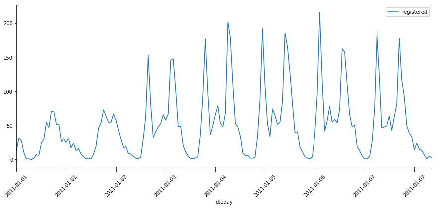

```python
fig, ax = plt.subplots(figsize=(15,6))
df_sel_week.plot(x = "dteday", y = "registered", ax=ax)
ax.tick_params(axis='x', labelrotation=45, length=10)
```

### Transformação de Dados

**Etapa 1:** selecionar as variáveis que vamos utilizar para construir o modelo de regressão. Vamos remover as variáveis que não vamos usar para simplificar a seleção de dados

```python
df.columns.values
```

```
array(['instant', 'dteday', 'season', 'yr', 'mnth', 'hr', 'holiday',
       'weekday', 'workingday', 'weathersit', 'temp', 'atemp', 'hum',
       'windspeed', 'casual', 'registered', 'cnt'], dtype=object)
```

```python
to_remove = ['instant','atemp', 'workingday', 'dteday','casual','cnt']
df_step1 = df.drop(to_remove, axis=1)
df_step1
```

|  | season | yr | mnth | hr | holiday | weekday | weathersit | temp | hum | windspeed | registered |
| --- | --- | --- | --- | --- | --- | --- | --- | --- | --- | --- | --- |
| 0 | 1 | 0 | 1 | 0 | 0 | 6 | 1 | 0.24 | 0.81 | 0.0000 | 13 |
| 1 | 1 | 0 | 1 | 1 | 0 | 6 | 1 | 0.22 | 0.80 | 0.0000 | 32 |
| 2 | 1 | 0 | 1 | 2 | 0 | 6 | 1 | 0.22 | 0.80 | 0.0000 | 27 |
| 3 | 1 | 0 | 1 | 3 | 0 | 6 | 1 | 0.24 | 0.75 | 0.0000 | 10 |
| 4 | 1 | 0 | 1 | 4 | 0 | 6 | 1 | 0.24 | 0.75 | 0.0000 | 1 |
| 5 | 1 | 0 | 1 | 5 | 0 | 6 | 2 | 0.24 | 0.75 | 0.0896 | 1 |
| 6 | 1 | 0 | 1 | 6 | 0 | 6 | 1 | 0.22 | 0.80 | 0.0000 | 0 |
| 7 | 1 | 0 | 1 | 7 | 0 | 6 | 1 | 0.20 | 0.86 | 0.0000 | 2 |
| 8 | 1 | 0 | 1 | 8 | 0 | 6 | 1 | 0.24 | 0.75 | 0.0000 | 7 |
| 9 | 1 | 0 | 1 | 9 | 0 | 6 | 1 | 0.32 | 0.76 | 0.0000 | 6 |
| 10 | 1 | 0 | 1 | 10 | 0 | 6 | 1 | 0.38 | 0.76 | 0.2537 | 24 |
| 11 | 1 | 0 | 1 | 11 | 0 | 6 | 1 | 0.36 | 0.81 | 0.2836 | 30 |
| 12 | 1 | 0 | 1 | 12 | 0 | 6 | 1 | 0.42 | 0.77 | 0.2836 | 55 |
| 13 | 1 | 0 | 1 | 13 | 0 | 6 | 2 | 0.46 | 0.72 | 0.2985 | 47 |
| 14 | 1 | 0 | 1 | 14 | 0 | 6 | 2 | 0.46 | 0.72 | 0.2836 | 71 |
| 15 | 1 | 0 | 1 | 15 | 0 | 6 | 2 | 0.44 | 0.77 | 0.2985 | 70 |
| 16 | 1 | 0 | 1 | 16 | 0 | 6 | 2 | 0.42 | 0.82 | 0.2985 | 52 |
| 17 | 1 | 0 | 1 | 17 | 0 | 6 | 2 | 0.44 | 0.82 | 0.2836 | 52 |
| 18 | 1 | 0 | 1 | 18 | 0 | 6 | 3 | 0.42 | 0.88 | 0.2537 | 26 |
| 19 | 1 | 0 | 1 | 19 | 0 | 6 | 3 | 0.42 | 0.88 | 0.2537 | 31 |
| 20 | 1 | 0 | 1 | 20 | 0 | 6 | 2 | 0.40 | 0.87 | 0.2537 | 25 |
| 21 | 1 | 0 | 1 | 21 | 0 | 6 | 2 | 0.40 | 0.87 | 0.1940 | 31 |
| 22 | 1 | 0 | 1 | 22 | 0 | 6 | 2 | 0.40 | 0.94 | 0.2239 | 17 |
| 23 | 1 | 0 | 1 | 23 | 0 | 6 | 2 | 0.46 | 0.88 | 0.2985 | 24 |
| 24 | 1 | 0 | 1 | 0 | 0 | 0 | 2 | 0.46 | 0.88 | 0.2985 | 13 |
| 25 | 1 | 0 | 1 | 1 | 0 | 0 | 2 | 0.44 | 0.94 | 0.2537 | 16 |
| 26 | 1 | 0 | 1 | 2 | 0 | 0 | 2 | 0.42 | 1.00 | 0.2836 | 8 |
| 27 | 1 | 0 | 1 | 3 | 0 | 0 | 2 | 0.46 | 0.94 | 0.1940 | 4 |
| 28 | 1 | 0 | 1 | 4 | 0 | 0 | 2 | 0.46 | 0.94 | 0.1940 | 1 |
| 29 | 1 | 0 | 1 | 6 | 0 | 0 | 3 | 0.42 | 0.77 | 0.2985 | 2 |
| ... | ... | ... | ... | ... | ... | ... | ... | ... | ... | ... | ... |
| 17349 | 1 | 1 | 12 | 18 | 0 | 0 | 2 | 0.24 | 0.44 | 0.2985 | 113 |
| 17350 | 1 | 1 | 12 | 19 | 0 | 0 | 1 | 0.34 | 0.61 | 0.0000 | 86 |
| 17351 | 1 | 1 | 12 | 20 | 0 | 0 | 1 | 0.22 | 0.47 | 0.3284 | 63 |
| 17352 | 1 | 1 | 12 | 21 | 0 | 0 | 1 | 0.20 | 0.51 | 0.1642 | 42 |
| 17353 | 1 | 1 | 12 | 22 | 0 | 0 | 1 | 0.20 | 0.55 | 0.1940 | 30 |
| 17354 | 1 | 1 | 12 | 23 | 0 | 0 | 1 | 0.20 | 0.51 | 0.2239 | 39 |
| 17355 | 1 | 1 | 12 | 0 | 0 | 1 | 1 | 0.18 | 0.55 | 0.1940 | 30 |
| 17356 | 1 | 1 | 12 | 1 | 0 | 1 | 1 | 0.18 | 0.55 | 0.1940 | 13 |
| 17357 | 1 | 1 | 12 | 2 | 0 | 1 | 1 | 0.16 | 0.59 | 0.1642 | 8 |
| 17358 | 1 | 1 | 12 | 3 | 0 | 1 | 1 | 0.16 | 0.59 | 0.1045 | 1 |
| 17359 | 1 | 1 | 12 | 4 | 0 | 1 | 1 | 0.14 | 0.69 | 0.1045 | 3 |
| 17360 | 1 | 1 | 12 | 5 | 0 | 1 | 1 | 0.16 | 0.64 | 0.1940 | 9 |
| 17361 | 1 | 1 | 12 | 6 | 0 | 1 | 1 | 0.16 | 0.64 | 0.1642 | 40 |
| 17362 | 1 | 1 | 12 | 7 | 0 | 1 | 1 | 0.16 | 0.64 | 0.1343 | 83 |
| 17363 | 1 | 1 | 12 | 8 | 0 | 1 | 1 | 0.14 | 0.69 | 0.1343 | 187 |
| 17364 | 1 | 1 | 12 | 9 | 0 | 1 | 2 | 0.18 | 0.64 | 0.1045 | 144 |
| 17365 | 1 | 1 | 12 | 10 | 0 | 1 | 2 | 0.20 | 0.69 | 0.1343 | 87 |
| 17366 | 1 | 1 | 12 | 11 | 0 | 1 | 2 | 0.22 | 0.60 | 0.1940 | 114 |
| 17367 | 1 | 1 | 12 | 12 | 0 | 1 | 2 | 0.24 | 0.56 | 0.1940 | 172 |
| 17368 | 1 | 1 | 12 | 13 | 0 | 1 | 2 | 0.26 | 0.44 | 0.1642 | 165 |
| 17369 | 1 | 1 | 12 | 14 | 0 | 1 | 2 | 0.28 | 0.45 | 0.2239 | 185 |
| 17370 | 1 | 1 | 12 | 15 | 0 | 1 | 2 | 0.28 | 0.45 | 0.1343 | 246 |
| 17371 | 1 | 1 | 12 | 16 | 0 | 1 | 2 | 0.26 | 0.48 | 0.1940 | 184 |
| 17372 | 1 | 1 | 12 | 17 | 0 | 1 | 2 | 0.26 | 0.48 | 0.0896 | 150 |
| 17373 | 1 | 1 | 12 | 18 | 0 | 1 | 2 | 0.26 | 0.48 | 0.1343 | 112 |
| 17374 | 1 | 1 | 12 | 19 | 0 | 1 | 2 | 0.26 | 0.60 | 0.1642 | 108 |
| 17375 | 1 | 1 | 12 | 20 | 0 | 1 | 2 | 0.26 | 0.60 | 0.1642 | 81 |
| 17376 | 1 | 1 | 12 | 21 | 0 | 1 | 1 | 0.26 | 0.60 | 0.1642 | 83 |
| 17377 | 1 | 1 | 12 | 22 | 0 | 1 | 1 | 0.26 | 0.56 | 0.1343 | 48 |
| 17378 | 1 | 1 | 12 | 23 | 0 | 1 | 1 | 0.26 | 0.65 | 0.1343 | 37 |

17379 rows × 11 columns

**Etapa 2:** transformar as variáveis categórias em variáveis `dummy` que são variáveis com valores 0 e 1. Por exemplo, a variável `weathersit` tem os valores 1, 2, 3 e 4, referente aos valores:

- 1: Clear, Few clouds, Partly cloudy, Partly cloudy
- 2: Mist + Cloudy, Mist + Broken clouds, Mist + Few clouds, Mist
- 3: Light Snow, Light Rain + Thunderstorm + Scattered clouds, Light Rain + Scattered clouds
- 4: Heavy Rain + Ice Pallets + Thunderstorm + Mist, Snow + Fog

Nesta etapa para cada valor criamos uma variável (coluna no nosso conjunto de dados)

```python
test = pd.get_dummies(df_step1['weathersit'], prefix='weathersit', drop_first=False)
test.head(20)
```

|  | weathersit_1 | weathersit_2 | weathersit_3 | weathersit_4 |
| --- | --- | --- | --- | --- |
| 0 | 1 | 0 | 0 | 0 |
| 1 | 1 | 0 | 0 | 0 |
| 2 | 1 | 0 | 0 | 0 |
| 3 | 1 | 0 | 0 | 0 |
| 4 | 1 | 0 | 0 | 0 |
| 5 | 0 | 1 | 0 | 0 |
| 6 | 1 | 0 | 0 | 0 |
| 7 | 1 | 0 | 0 | 0 |
| 8 | 1 | 0 | 0 | 0 |
| 9 | 1 | 0 | 0 | 0 |
| 10 | 1 | 0 | 0 | 0 |
| 11 | 1 | 0 | 0 | 0 |
| 12 | 1 | 0 | 0 | 0 |
| 13 | 0 | 1 | 0 | 0 |
| 14 | 0 | 1 | 0 | 0 |
| 15 | 0 | 1 | 0 | 0 |
| 16 | 0 | 1 | 0 | 0 |
| 17 | 0 | 1 | 0 | 0 |
| 18 | 0 | 0 | 1 | 0 |
| 19 | 0 | 0 | 1 | 0 |

Vamos construir um novo conjunto de dados transformando dessa forma as variáveis `season`, `weathersit`, `mnth`, `hr`, `weekday`.

```python
dummy_fields = ['season', 'weathersit', 'mnth', 'hr', 'weekday']
df_step2 = df_step1
for each in dummy_fields:
    dummies = pd.get_dummies(df_step2[each], prefix=each, drop_first=False)
    df_step2 = pd.concat([df_step2, dummies], axis=1)

df_step2 = df_step2.drop(dummy_fields, axis=1)
df_step2
```

|  | yr | holiday | temp | hum | windspeed | registered | season_1 | season_2 | season_3 | season_4 | ... | hr_21 | hr_22 | hr_23 | weekday_0 | weekday_1 | weekday_2 | weekday_3 | weekday_4 | weekday_5 | weekday_6 |
| --- | --- | --- | --- | --- | --- | --- | --- | --- | --- | --- | --- | --- | --- | --- | --- | --- | --- | --- | --- | --- | --- |
| 0 | 0 | 0 | 0.24 | 0.81 | 0.0000 | 13 | 1 | 0 | 0 | 0 | ... | 0 | 0 | 0 | 0 | 0 | 0 | 0 | 0 | 0 | 1 |
| 1 | 0 | 0 | 0.22 | 0.80 | 0.0000 | 32 | 1 | 0 | 0 | 0 | ... | 0 | 0 | 0 | 0 | 0 | 0 | 0 | 0 | 0 | 1 |
| 2 | 0 | 0 | 0.22 | 0.80 | 0.0000 | 27 | 1 | 0 | 0 | 0 | ... | 0 | 0 | 0 | 0 | 0 | 0 | 0 | 0 | 0 | 1 |
| 3 | 0 | 0 | 0.24 | 0.75 | 0.0000 | 10 | 1 | 0 | 0 | 0 | ... | 0 | 0 | 0 | 0 | 0 | 0 | 0 | 0 | 0 | 1 |
| 4 | 0 | 0 | 0.24 | 0.75 | 0.0000 | 1 | 1 | 0 | 0 | 0 | ... | 0 | 0 | 0 | 0 | 0 | 0 | 0 | 0 | 0 | 1 |
| 5 | 0 | 0 | 0.24 | 0.75 | 0.0896 | 1 | 1 | 0 | 0 | 0 | ... | 0 | 0 | 0 | 0 | 0 | 0 | 0 | 0 | 0 | 1 |
| 6 | 0 | 0 | 0.22 | 0.80 | 0.0000 | 0 | 1 | 0 | 0 | 0 | ... | 0 | 0 | 0 | 0 | 0 | 0 | 0 | 0 | 0 | 1 |
| 7 | 0 | 0 | 0.20 | 0.86 | 0.0000 | 2 | 1 | 0 | 0 | 0 | ... | 0 | 0 | 0 | 0 | 0 | 0 | 0 | 0 | 0 | 1 |
| 8 | 0 | 0 | 0.24 | 0.75 | 0.0000 | 7 | 1 | 0 | 0 | 0 | ... | 0 | 0 | 0 | 0 | 0 | 0 | 0 | 0 | 0 | 1 |
| 9 | 0 | 0 | 0.32 | 0.76 | 0.0000 | 6 | 1 | 0 | 0 | 0 | ... | 0 | 0 | 0 | 0 | 0 | 0 | 0 | 0 | 0 | 1 |
| 10 | 0 | 0 | 0.38 | 0.76 | 0.2537 | 24 | 1 | 0 | 0 | 0 | ... | 0 | 0 | 0 | 0 | 0 | 0 | 0 | 0 | 0 | 1 |
| 11 | 0 | 0 | 0.36 | 0.81 | 0.2836 | 30 | 1 | 0 | 0 | 0 | ... | 0 | 0 | 0 | 0 | 0 | 0 | 0 | 0 | 0 | 1 |
| 12 | 0 | 0 | 0.42 | 0.77 | 0.2836 | 55 | 1 | 0 | 0 | 0 | ... | 0 | 0 | 0 | 0 | 0 | 0 | 0 | 0 | 0 | 1 |
| 13 | 0 | 0 | 0.46 | 0.72 | 0.2985 | 47 | 1 | 0 | 0 | 0 | ... | 0 | 0 | 0 | 0 | 0 | 0 | 0 | 0 | 0 | 1 |
| 14 | 0 | 0 | 0.46 | 0.72 | 0.2836 | 71 | 1 | 0 | 0 | 0 | ... | 0 | 0 | 0 | 0 | 0 | 0 | 0 | 0 | 0 | 1 |
| 15 | 0 | 0 | 0.44 | 0.77 | 0.2985 | 70 | 1 | 0 | 0 | 0 | ... | 0 | 0 | 0 | 0 | 0 | 0 | 0 | 0 | 0 | 1 |
| 16 | 0 | 0 | 0.42 | 0.82 | 0.2985 | 52 | 1 | 0 | 0 | 0 | ... | 0 | 0 | 0 | 0 | 0 | 0 | 0 | 0 | 0 | 1 |
| 17 | 0 | 0 | 0.44 | 0.82 | 0.2836 | 52 | 1 | 0 | 0 | 0 | ... | 0 | 0 | 0 | 0 | 0 | 0 | 0 | 0 | 0 | 1 |
| 18 | 0 | 0 | 0.42 | 0.88 | 0.2537 | 26 | 1 | 0 | 0 | 0 | ... | 0 | 0 | 0 | 0 | 0 | 0 | 0 | 0 | 0 | 1 |
| 19 | 0 | 0 | 0.42 | 0.88 | 0.2537 | 31 | 1 | 0 | 0 | 0 | ... | 0 | 0 | 0 | 0 | 0 | 0 | 0 | 0 | 0 | 1 |
| 20 | 0 | 0 | 0.40 | 0.87 | 0.2537 | 25 | 1 | 0 | 0 | 0 | ... | 0 | 0 | 0 | 0 | 0 | 0 | 0 | 0 | 0 | 1 |
| 21 | 0 | 0 | 0.40 | 0.87 | 0.1940 | 31 | 1 | 0 | 0 | 0 | ... | 1 | 0 | 0 | 0 | 0 | 0 | 0 | 0 | 0 | 1 |
| 22 | 0 | 0 | 0.40 | 0.94 | 0.2239 | 17 | 1 | 0 | 0 | 0 | ... | 0 | 1 | 0 | 0 | 0 | 0 | 0 | 0 | 0 | 1 |
| 23 | 0 | 0 | 0.46 | 0.88 | 0.2985 | 24 | 1 | 0 | 0 | 0 | ... | 0 | 0 | 1 | 0 | 0 | 0 | 0 | 0 | 0 | 1 |
| 24 | 0 | 0 | 0.46 | 0.88 | 0.2985 | 13 | 1 | 0 | 0 | 0 | ... | 0 | 0 | 0 | 1 | 0 | 0 | 0 | 0 | 0 | 0 |
| 25 | 0 | 0 | 0.44 | 0.94 | 0.2537 | 16 | 1 | 0 | 0 | 0 | ... | 0 | 0 | 0 | 1 | 0 | 0 | 0 | 0 | 0 | 0 |
| 26 | 0 | 0 | 0.42 | 1.00 | 0.2836 | 8 | 1 | 0 | 0 | 0 | ... | 0 | 0 | 0 | 1 | 0 | 0 | 0 | 0 | 0 | 0 |
| 27 | 0 | 0 | 0.46 | 0.94 | 0.1940 | 4 | 1 | 0 | 0 | 0 | ... | 0 | 0 | 0 | 1 | 0 | 0 | 0 | 0 | 0 | 0 |
| 28 | 0 | 0 | 0.46 | 0.94 | 0.1940 | 1 | 1 | 0 | 0 | 0 | ... | 0 | 0 | 0 | 1 | 0 | 0 | 0 | 0 | 0 | 0 |
| 29 | 0 | 0 | 0.42 | 0.77 | 0.2985 | 2 | 1 | 0 | 0 | 0 | ... | 0 | 0 | 0 | 1 | 0 | 0 | 0 | 0 | 0 | 0 |
| ... | ... | ... | ... | ... | ... | ... | ... | ... | ... | ... | ... | ... | ... | ... | ... | ... | ... | ... | ... | ... | ... |
| 17349 | 1 | 0 | 0.24 | 0.44 | 0.2985 | 113 | 1 | 0 | 0 | 0 | ... | 0 | 0 | 0 | 1 | 0 | 0 | 0 | 0 | 0 | 0 |
| 17350 | 1 | 0 | 0.34 | 0.61 | 0.0000 | 86 | 1 | 0 | 0 | 0 | ... | 0 | 0 | 0 | 1 | 0 | 0 | 0 | 0 | 0 | 0 |
| 17351 | 1 | 0 | 0.22 | 0.47 | 0.3284 | 63 | 1 | 0 | 0 | 0 | ... | 0 | 0 | 0 | 1 | 0 | 0 | 0 | 0 | 0 | 0 |
| 17352 | 1 | 0 | 0.20 | 0.51 | 0.1642 | 42 | 1 | 0 | 0 | 0 | ... | 1 | 0 | 0 | 1 | 0 | 0 | 0 | 0 | 0 | 0 |
| 17353 | 1 | 0 | 0.20 | 0.55 | 0.1940 | 30 | 1 | 0 | 0 | 0 | ... | 0 | 1 | 0 | 1 | 0 | 0 | 0 | 0 | 0 | 0 |
| 17354 | 1 | 0 | 0.20 | 0.51 | 0.2239 | 39 | 1 | 0 | 0 | 0 | ... | 0 | 0 | 1 | 1 | 0 | 0 | 0 | 0 | 0 | 0 |
| 17355 | 1 | 0 | 0.18 | 0.55 | 0.1940 | 30 | 1 | 0 | 0 | 0 | ... | 0 | 0 | 0 | 0 | 1 | 0 | 0 | 0 | 0 | 0 |
| 17356 | 1 | 0 | 0.18 | 0.55 | 0.1940 | 13 | 1 | 0 | 0 | 0 | ... | 0 | 0 | 0 | 0 | 1 | 0 | 0 | 0 | 0 | 0 |
| 17357 | 1 | 0 | 0.16 | 0.59 | 0.1642 | 8 | 1 | 0 | 0 | 0 | ... | 0 | 0 | 0 | 0 | 1 | 0 | 0 | 0 | 0 | 0 |
| 17358 | 1 | 0 | 0.16 | 0.59 | 0.1045 | 1 | 1 | 0 | 0 | 0 | ... | 0 | 0 | 0 | 0 | 1 | 0 | 0 | 0 | 0 | 0 |
| 17359 | 1 | 0 | 0.14 | 0.69 | 0.1045 | 3 | 1 | 0 | 0 | 0 | ... | 0 | 0 | 0 | 0 | 1 | 0 | 0 | 0 | 0 | 0 |
| 17360 | 1 | 0 | 0.16 | 0.64 | 0.1940 | 9 | 1 | 0 | 0 | 0 | ... | 0 | 0 | 0 | 0 | 1 | 0 | 0 | 0 | 0 | 0 |
| 17361 | 1 | 0 | 0.16 | 0.64 | 0.1642 | 40 | 1 | 0 | 0 | 0 | ... | 0 | 0 | 0 | 0 | 1 | 0 | 0 | 0 | 0 | 0 |
| 17362 | 1 | 0 | 0.16 | 0.64 | 0.1343 | 83 | 1 | 0 | 0 | 0 | ... | 0 | 0 | 0 | 0 | 1 | 0 | 0 | 0 | 0 | 0 |
| 17363 | 1 | 0 | 0.14 | 0.69 | 0.1343 | 187 | 1 | 0 | 0 | 0 | ... | 0 | 0 | 0 | 0 | 1 | 0 | 0 | 0 | 0 | 0 |
| 17364 | 1 | 0 | 0.18 | 0.64 | 0.1045 | 144 | 1 | 0 | 0 | 0 | ... | 0 | 0 | 0 | 0 | 1 | 0 | 0 | 0 | 0 | 0 |
| 17365 | 1 | 0 | 0.20 | 0.69 | 0.1343 | 87 | 1 | 0 | 0 | 0 | ... | 0 | 0 | 0 | 0 | 1 | 0 | 0 | 0 | 0 | 0 |
| 17366 | 1 | 0 | 0.22 | 0.60 | 0.1940 | 114 | 1 | 0 | 0 | 0 | ... | 0 | 0 | 0 | 0 | 1 | 0 | 0 | 0 | 0 | 0 |
| 17367 | 1 | 0 | 0.24 | 0.56 | 0.1940 | 172 | 1 | 0 | 0 | 0 | ... | 0 | 0 | 0 | 0 | 1 | 0 | 0 | 0 | 0 | 0 |
| 17368 | 1 | 0 | 0.26 | 0.44 | 0.1642 | 165 | 1 | 0 | 0 | 0 | ... | 0 | 0 | 0 | 0 | 1 | 0 | 0 | 0 | 0 | 0 |
| 17369 | 1 | 0 | 0.28 | 0.45 | 0.2239 | 185 | 1 | 0 | 0 | 0 | ... | 0 | 0 | 0 | 0 | 1 | 0 | 0 | 0 | 0 | 0 |
| 17370 | 1 | 0 | 0.28 | 0.45 | 0.1343 | 246 | 1 | 0 | 0 | 0 | ... | 0 | 0 | 0 | 0 | 1 | 0 | 0 | 0 | 0 | 0 |
| 17371 | 1 | 0 | 0.26 | 0.48 | 0.1940 | 184 | 1 | 0 | 0 | 0 | ... | 0 | 0 | 0 | 0 | 1 | 0 | 0 | 0 | 0 | 0 |
| 17372 | 1 | 0 | 0.26 | 0.48 | 0.0896 | 150 | 1 | 0 | 0 | 0 | ... | 0 | 0 | 0 | 0 | 1 | 0 | 0 | 0 | 0 | 0 |
| 17373 | 1 | 0 | 0.26 | 0.48 | 0.1343 | 112 | 1 | 0 | 0 | 0 | ... | 0 | 0 | 0 | 0 | 1 | 0 | 0 | 0 | 0 | 0 |
| 17374 | 1 | 0 | 0.26 | 0.60 | 0.1642 | 108 | 1 | 0 | 0 | 0 | ... | 0 | 0 | 0 | 0 | 1 | 0 | 0 | 0 | 0 | 0 |
| 17375 | 1 | 0 | 0.26 | 0.60 | 0.1642 | 81 | 1 | 0 | 0 | 0 | ... | 0 | 0 | 0 | 0 | 1 | 0 | 0 | 0 | 0 | 0 |
| 17376 | 1 | 0 | 0.26 | 0.60 | 0.1642 | 83 | 1 | 0 | 0 | 0 | ... | 1 | 0 | 0 | 0 | 1 | 0 | 0 | 0 | 0 | 0 |
| 17377 | 1 | 0 | 0.26 | 0.56 | 0.1343 | 48 | 1 | 0 | 0 | 0 | ... | 0 | 1 | 0 | 0 | 1 | 0 | 0 | 0 | 0 | 0 |
| 17378 | 1 | 0 | 0.26 | 0.65 | 0.1343 | 37 | 1 | 0 | 0 | 0 | ... | 0 | 0 | 1 | 0 | 1 | 0 | 0 | 0 | 0 | 0 |

17379 rows × 57 columns

```python
from sklearn.preprocessing import StandardScaler
scaler = StandardScaler()

#from sklearn.preprocessing import MinMaxScaler
#scaler = MinMaxScaler()
df_step3 = df_step2

to_scale = ['registered','temp', 'hum', 'windspeed']
scaler.fit(df_step3[to_scale])
scaled = scaler.transform(df_step3[to_scale])
df_step3[to_scale] = scaled
df_step3
```

|  | yr | holiday | temp | hum | windspeed | registered | season_1 | season_2 | season_3 | season_4 | ... | hr_21 | hr_22 | hr_23 | weekday_0 | weekday_1 | weekday_2 | weekday_3 | weekday_4 | weekday_5 | weekday_6 |
| --- | --- | --- | --- | --- | --- | --- | --- | --- | --- | --- | --- | --- | --- | --- | --- | --- | --- | --- | --- | --- | --- |
| 0 | 0 | 0 | -1.334648 | 0.947372 | -1.553889 | -0.930189 | 1 | 0 | 0 | 0 | ... | 0 | 0 | 0 | 0 | 0 | 0 | 0 | 0 | 0 | 1 |
| 1 | 0 | 0 | -1.438516 | 0.895539 | -1.553889 | -0.804655 | 1 | 0 | 0 | 0 | ... | 0 | 0 | 0 | 0 | 0 | 0 | 0 | 0 | 0 | 1 |
| 2 | 0 | 0 | -1.438516 | 0.895539 | -1.553889 | -0.837690 | 1 | 0 | 0 | 0 | ... | 0 | 0 | 0 | 0 | 0 | 0 | 0 | 0 | 0 | 1 |
| 3 | 0 | 0 | -1.334648 | 0.636370 | -1.553889 | -0.950010 | 1 | 0 | 0 | 0 | ... | 0 | 0 | 0 | 0 | 0 | 0 | 0 | 0 | 0 | 1 |
| 4 | 0 | 0 | -1.334648 | 0.636370 | -1.553889 | -1.009474 | 1 | 0 | 0 | 0 | ... | 0 | 0 | 0 | 0 | 0 | 0 | 0 | 0 | 0 | 1 |
| 5 | 0 | 0 | -1.334648 | 0.636370 | -0.821484 | -1.009474 | 1 | 0 | 0 | 0 | ... | 0 | 0 | 0 | 0 | 0 | 0 | 0 | 0 | 0 | 1 |
| 6 | 0 | 0 | -1.438516 | 0.895539 | -1.553889 | -1.016081 | 1 | 0 | 0 | 0 | ... | 0 | 0 | 0 | 0 | 0 | 0 | 0 | 0 | 0 | 1 |
| 7 | 0 | 0 | -1.542385 | 1.206542 | -1.553889 | -1.002867 | 1 | 0 | 0 | 0 | ... | 0 | 0 | 0 | 0 | 0 | 0 | 0 | 0 | 0 | 1 |
| 8 | 0 | 0 | -1.334648 | 0.636370 | -1.553889 | -0.969832 | 1 | 0 | 0 | 0 | ... | 0 | 0 | 0 | 0 | 0 | 0 | 0 | 0 | 0 | 1 |
| 9 | 0 | 0 | -0.919172 | 0.688203 | -1.553889 | -0.976439 | 1 | 0 | 0 | 0 | ... | 0 | 0 | 0 | 0 | 0 | 0 | 0 | 0 | 0 | 1 |
| 10 | 0 | 0 | -0.607566 | 0.688203 | 0.519896 | -0.857511 | 1 | 0 | 0 | 0 | ... | 0 | 0 | 0 | 0 | 0 | 0 | 0 | 0 | 0 | 1 |
| 11 | 0 | 0 | -0.711435 | 0.947372 | 0.764304 | -0.817869 | 1 | 0 | 0 | 0 | ... | 0 | 0 | 0 | 0 | 0 | 0 | 0 | 0 | 0 | 1 |
| 12 | 0 | 0 | -0.399828 | 0.740037 | 0.764304 | -0.652692 | 1 | 0 | 0 | 0 | ... | 0 | 0 | 0 | 0 | 0 | 0 | 0 | 0 | 0 | 1 |
| 13 | 0 | 0 | -0.192091 | 0.480868 | 0.886099 | -0.705549 | 1 | 0 | 0 | 0 | ... | 0 | 0 | 0 | 0 | 0 | 0 | 0 | 0 | 0 | 1 |
| 14 | 0 | 0 | -0.192091 | 0.480868 | 0.764304 | -0.546979 | 1 | 0 | 0 | 0 | ... | 0 | 0 | 0 | 0 | 0 | 0 | 0 | 0 | 0 | 1 |
| 15 | 0 | 0 | -0.295959 | 0.740037 | 0.886099 | -0.553586 | 1 | 0 | 0 | 0 | ... | 0 | 0 | 0 | 0 | 0 | 0 | 0 | 0 | 0 | 1 |
| 16 | 0 | 0 | -0.399828 | 0.999206 | 0.886099 | -0.672513 | 1 | 0 | 0 | 0 | ... | 0 | 0 | 0 | 0 | 0 | 0 | 0 | 0 | 0 | 1 |
| 17 | 0 | 0 | -0.295959 | 0.999206 | 0.764304 | -0.672513 | 1 | 0 | 0 | 0 | ... | 0 | 0 | 0 | 0 | 0 | 0 | 0 | 0 | 0 | 1 |
| 18 | 0 | 0 | -0.399828 | 1.310209 | 0.519896 | -0.844297 | 1 | 0 | 0 | 0 | ... | 0 | 0 | 0 | 0 | 0 | 0 | 0 | 0 | 0 | 1 |
| 19 | 0 | 0 | -0.399828 | 1.310209 | 0.519896 | -0.811262 | 1 | 0 | 0 | 0 | ... | 0 | 0 | 0 | 0 | 0 | 0 | 0 | 0 | 0 | 1 |
| 20 | 0 | 0 | -0.503697 | 1.258375 | 0.519896 | -0.850904 | 1 | 0 | 0 | 0 | ... | 0 | 0 | 0 | 0 | 0 | 0 | 0 | 0 | 0 | 1 |
| 21 | 0 | 0 | -0.503697 | 1.258375 | 0.031899 | -0.811262 | 1 | 0 | 0 | 0 | ... | 1 | 0 | 0 | 0 | 0 | 0 | 0 | 0 | 0 | 1 |
| 22 | 0 | 0 | -0.503697 | 1.621212 | 0.276306 | -0.903761 | 1 | 0 | 0 | 0 | ... | 0 | 1 | 0 | 0 | 0 | 0 | 0 | 0 | 0 | 1 |
| 23 | 0 | 0 | -0.192091 | 1.310209 | 0.886099 | -0.857511 | 1 | 0 | 0 | 0 | ... | 0 | 0 | 1 | 0 | 0 | 0 | 0 | 0 | 0 | 1 |
| 24 | 0 | 0 | -0.192091 | 1.310209 | 0.886099 | -0.930189 | 1 | 0 | 0 | 0 | ... | 0 | 0 | 0 | 1 | 0 | 0 | 0 | 0 | 0 | 0 |
| 25 | 0 | 0 | -0.295959 | 1.621212 | 0.519896 | -0.910368 | 1 | 0 | 0 | 0 | ... | 0 | 0 | 0 | 1 | 0 | 0 | 0 | 0 | 0 | 0 |
| 26 | 0 | 0 | -0.399828 | 1.932215 | 0.764304 | -0.963225 | 1 | 0 | 0 | 0 | ... | 0 | 0 | 0 | 1 | 0 | 0 | 0 | 0 | 0 | 0 |
| 27 | 0 | 0 | -0.192091 | 1.621212 | 0.031899 | -0.989653 | 1 | 0 | 0 | 0 | ... | 0 | 0 | 0 | 1 | 0 | 0 | 0 | 0 | 0 | 0 |
| 28 | 0 | 0 | -0.192091 | 1.621212 | 0.031899 | -1.009474 | 1 | 0 | 0 | 0 | ... | 0 | 0 | 0 | 1 | 0 | 0 | 0 | 0 | 0 | 0 |
| 29 | 0 | 0 | -0.399828 | 0.740037 | 0.886099 | -1.002867 | 1 | 0 | 0 | 0 | ... | 0 | 0 | 0 | 1 | 0 | 0 | 0 | 0 | 0 | 0 |
| ... | ... | ... | ... | ... | ... | ... | ... | ... | ... | ... | ... | ... | ... | ... | ... | ... | ... | ... | ... | ... | ... |
| 17349 | 1 | 0 | -1.334648 | -0.970478 | 0.886099 | -0.269482 | 1 | 0 | 0 | 0 | ... | 0 | 0 | 0 | 1 | 0 | 0 | 0 | 0 | 0 | 0 |
| 17350 | 1 | 0 | -0.815304 | -0.089304 | -1.553889 | -0.447873 | 1 | 0 | 0 | 0 | ... | 0 | 0 | 0 | 1 | 0 | 0 | 0 | 0 | 0 | 0 |
| 17351 | 1 | 0 | -1.438516 | -0.814977 | 1.130506 | -0.599836 | 1 | 0 | 0 | 0 | ... | 0 | 0 | 0 | 1 | 0 | 0 | 0 | 0 | 0 | 0 |
| 17352 | 1 | 0 | -1.542385 | -0.607642 | -0.211691 | -0.738584 | 1 | 0 | 0 | 0 | ... | 1 | 0 | 0 | 1 | 0 | 0 | 0 | 0 | 0 | 0 |
| 17353 | 1 | 0 | -1.542385 | -0.400306 | 0.031899 | -0.817869 | 1 | 0 | 0 | 0 | ... | 0 | 1 | 0 | 1 | 0 | 0 | 0 | 0 | 0 | 0 |
| 17354 | 1 | 0 | -1.542385 | -0.607642 | 0.276306 | -0.758405 | 1 | 0 | 0 | 0 | ... | 0 | 0 | 1 | 1 | 0 | 0 | 0 | 0 | 0 | 0 |
| 17355 | 1 | 0 | -1.646254 | -0.400306 | 0.031899 | -0.817869 | 1 | 0 | 0 | 0 | ... | 0 | 0 | 0 | 0 | 1 | 0 | 0 | 0 | 0 | 0 |
| 17356 | 1 | 0 | -1.646254 | -0.400306 | 0.031899 | -0.930189 | 1 | 0 | 0 | 0 | ... | 0 | 0 | 0 | 0 | 1 | 0 | 0 | 0 | 0 | 0 |
| 17357 | 1 | 0 | -1.750123 | -0.192971 | -0.211691 | -0.963225 | 1 | 0 | 0 | 0 | ... | 0 | 0 | 0 | 0 | 1 | 0 | 0 | 0 | 0 | 0 |
| 17358 | 1 | 0 | -1.750123 | -0.192971 | -0.699689 | -1.009474 | 1 | 0 | 0 | 0 | ... | 0 | 0 | 0 | 0 | 1 | 0 | 0 | 0 | 0 | 0 |
| 17359 | 1 | 0 | -1.853992 | 0.325367 | -0.699689 | -0.996260 | 1 | 0 | 0 | 0 | ... | 0 | 0 | 0 | 0 | 1 | 0 | 0 | 0 | 0 | 0 |
| 17360 | 1 | 0 | -1.750123 | 0.066198 | 0.031899 | -0.956618 | 1 | 0 | 0 | 0 | ... | 0 | 0 | 0 | 0 | 1 | 0 | 0 | 0 | 0 | 0 |
| 17361 | 1 | 0 | -1.750123 | 0.066198 | -0.211691 | -0.751798 | 1 | 0 | 0 | 0 | ... | 0 | 0 | 0 | 0 | 1 | 0 | 0 | 0 | 0 | 0 |
| 17362 | 1 | 0 | -1.750123 | 0.066198 | -0.456099 | -0.467694 | 1 | 0 | 0 | 0 | ... | 0 | 0 | 0 | 0 | 1 | 0 | 0 | 0 | 0 | 0 |
| 17363 | 1 | 0 | -1.853992 | 0.325367 | -0.456099 | 0.219442 | 1 | 0 | 0 | 0 | ... | 0 | 0 | 0 | 0 | 1 | 0 | 0 | 0 | 0 | 0 |
| 17364 | 1 | 0 | -1.646254 | 0.066198 | -0.699689 | -0.064663 | 1 | 0 | 0 | 0 | ... | 0 | 0 | 0 | 0 | 1 | 0 | 0 | 0 | 0 | 0 |
| 17365 | 1 | 0 | -1.542385 | 0.325367 | -0.456099 | -0.441266 | 1 | 0 | 0 | 0 | ... | 0 | 0 | 0 | 0 | 1 | 0 | 0 | 0 | 0 | 0 |
| 17366 | 1 | 0 | -1.438516 | -0.141137 | 0.031899 | -0.262875 | 1 | 0 | 0 | 0 | ... | 0 | 0 | 0 | 0 | 1 | 0 | 0 | 0 | 0 | 0 |
| 17367 | 1 | 0 | -1.334648 | -0.348473 | 0.031899 | 0.120336 | 1 | 0 | 0 | 0 | ... | 0 | 0 | 0 | 0 | 1 | 0 | 0 | 0 | 0 | 0 |
| 17368 | 1 | 0 | -1.230779 | -0.970478 | -0.211691 | 0.074086 | 1 | 0 | 0 | 0 | ... | 0 | 0 | 0 | 0 | 1 | 0 | 0 | 0 | 0 | 0 |
| 17369 | 1 | 0 | -1.126910 | -0.918645 | 0.276306 | 0.206227 | 1 | 0 | 0 | 0 | ... | 0 | 0 | 0 | 0 | 1 | 0 | 0 | 0 | 0 | 0 |
| 17370 | 1 | 0 | -1.126910 | -0.918645 | -0.456099 | 0.609259 | 1 | 0 | 0 | 0 | ... | 0 | 0 | 0 | 0 | 1 | 0 | 0 | 0 | 0 | 0 |
| 17371 | 1 | 0 | -1.230779 | -0.763143 | 0.031899 | 0.199620 | 1 | 0 | 0 | 0 | ... | 0 | 0 | 0 | 0 | 1 | 0 | 0 | 0 | 0 | 0 |
| 17372 | 1 | 0 | -1.230779 | -0.763143 | -0.821484 | -0.025020 | 1 | 0 | 0 | 0 | ... | 0 | 0 | 0 | 0 | 1 | 0 | 0 | 0 | 0 | 0 |
| 17373 | 1 | 0 | -1.230779 | -0.763143 | -0.456099 | -0.276089 | 1 | 0 | 0 | 0 | ... | 0 | 0 | 0 | 0 | 1 | 0 | 0 | 0 | 0 | 0 |
| 17374 | 1 | 0 | -1.230779 | -0.141137 | -0.211691 | -0.302517 | 1 | 0 | 0 | 0 | ... | 0 | 0 | 0 | 0 | 1 | 0 | 0 | 0 | 0 | 0 |
| 17375 | 1 | 0 | -1.230779 | -0.141137 | -0.211691 | -0.480908 | 1 | 0 | 0 | 0 | ... | 0 | 0 | 0 | 0 | 1 | 0 | 0 | 0 | 0 | 0 |
| 17376 | 1 | 0 | -1.230779 | -0.141137 | -0.211691 | -0.467694 | 1 | 0 | 0 | 0 | ... | 1 | 0 | 0 | 0 | 1 | 0 | 0 | 0 | 0 | 0 |
| 17377 | 1 | 0 | -1.230779 | -0.348473 | -0.456099 | -0.698942 | 1 | 0 | 0 | 0 | ... | 0 | 1 | 0 | 0 | 1 | 0 | 0 | 0 | 0 | 0 |
| 17378 | 1 | 0 | -1.230779 | 0.118032 | -0.456099 | -0.771619 | 1 | 0 | 0 | 0 | ... | 0 | 0 | 1 | 0 | 1 | 0 | 0 | 0 | 0 | 0 |

17379 rows × 57 columns

### Separando dados de Treinamento e de Teste

- Como conjunto de dados de **Treinamento** vamos considerar os dados entre 2011-01-01 e 2012-10-31
- Como conjunto de dados de **Teste** vamos considerar os dados entre 2012-11-01 e 2012-12-31

```python
from sklearn.model_selection import train_test_split

target = 'registered'
X = df_step3.drop(target,axis=1)
y = df_step3[target]

X_train, X_test, y_train, y_test = train_test_split(X, y, test_size=60*24, shuffle=False)
```

- Criamos TensorDataset para cada um dos conjunto de dados. Temos que realizar uma transformação dos dados para `np.float32` pois no `DataFrame` temos algumas colunas como valores inteiros.
- Além disso esses dois conjuntos poderão ser utilizados para construir `DataLoaders` que facilitam o treinamento da Rede Neural.

```python
import torch
from torch.utils.data import TensorDataset
import numpy as np

train = TensorDataset(
    torch.tensor( X_train.values.astype(np.float32) ),
    torch.tensor( y_train.values.astype(np.float32) )
)

test = TensorDataset(
    torch.tensor( X_test.values.astype(np.float32) ),
    torch.tensor( y_test.values.astype(np.float32) )
)
```

### Criando a Rede Neural

```python
from torch import nn
class Network_BikeSharing_1(nn.Module):
    def __init__(self):
        super().__init__()
        # From 56 to 20
        self.fc1 = nn.Linear(in_features=56, out_features=20)
        # From 20 to 1
        self.fc2 = nn.Linear(in_features=20, out_features=1)

    def forward(self, x):
        # O input passa pela primeira camada
        x = torch.sigmoid( self.fc1(x) )
        # O input passa pela segunda camada
        x = self.fc2(x)
        return x
```

### Treinamento da Rede Neural

Primeiro implementamos a função que treina uma única época da rede neural usando um DataLoader.

```python
def train_epoch(model, loader, optimizer, criterion):
    model.train()
    losses = []

    for X_batch, y_batch in loader:

        optimizer.zero_grad()
        # (1) Forward
        y_pred = model(X_batch)
        # (2) Compute error
        loss = criterion(y_pred.squeeze(), y_batch)
        # (3) Compute gradients
        loss.backward()
        # (4) Update weights
        optimizer.step()

        losses.append(loss.item())

    model.eval()
    return np.mean(losses)
```

Posteriormente construímos uma função para a avaliar uma rede neural (sem treinar) usando um DataLoader.

```python
def eval_model(model, loader):
    losses = []
    for X_batch, y_batch in loader:

        # (1) Forward
        y_pred = model(X_batch)
        # (2) Compute error
        loss = criterion(y_pred.squeeze(), y_batch)
        losses.append(loss.item())

    return np.mean(losses)
```

Configuração de parâmetros do treinamento da rede neural. Como estamos tratando um problema de regressão vamos utilizar a medida de erro MSELoss (*Mean Squared Error*).

```python
from torch import optim
from torch.utils.data import DataLoader

lr = 0.1
batch_size = 64
num_epochs = 100

model = Network_BikeSharing_1()
criterion = nn.MSELoss()
optimizer = optim.SGD(model.parameters(), lr=lr)

loader_train = DataLoader(train, batch_size=batch_size)
loader_test  = DataLoader(test , batch_size=batch_size)
```

Treinamento da rede neural e visualização de Loss durante o treinamento.

```python
import sys

train_losses = []
test_losses = []

for e in range(num_epochs):
    train_loss =  train_epoch(model, loader_train, optimizer, criterion)
    train_losses += [train_loss]

    test_loss  = eval_model(model, loader_test)
    test_losses += [test_loss]

    sys.stdout.write("\rProgress: {:2.1f}".format(100.0 * (e+1) / num_epochs) \
                     + "% ... Training loss: " + str(train_loss)[:5] \
                     + " ... Testing loss: " + str(test_loss)[:5] )
    sys.stdout.flush()
```

```
Progress: 100.0% ... Training loss: 0.061 ... Testing loss: 0.327
```

### Training Loss vs. Test Loss

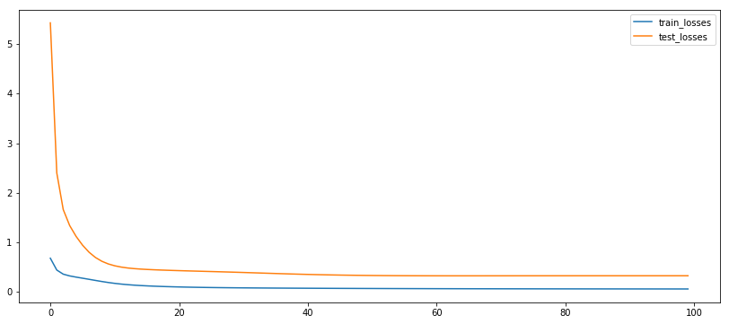

```python
fig, ax = plt.subplots(figsize=(14,6))
ax.plot(train_losses, label='train_losses')
ax.plot(test_losses , label='test_losses')
ax.legend()
```

### MSELoss no Conjunto de Treinamento

```python
eval_model(model, loader_train)
```

```
0.09017211812362075
```

### MSELoss no Conjunto de Teste

```python
eval_model(model, loader_test)
```

```
0.32768534804167954
```

### Visualização dos Primeiros 15 dias (no Conjunto de Treino)

```python
X_train_torch = torch.tensor( X_train[:24*15].values.astype(np.float32) )
y_pred = model(X_train_torch)
```

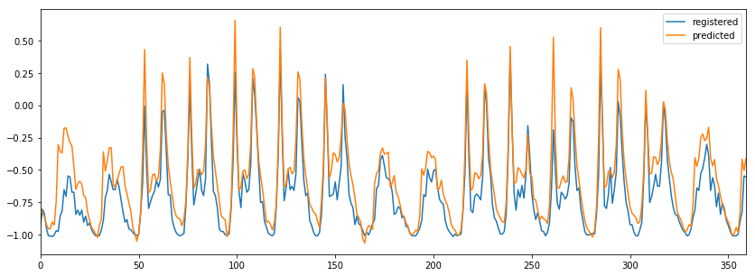

```python
results = pd.DataFrame(y_train[:24*15])
results['predicted'] = y_pred.detach().numpy()

fig, ax = plt.subplots(figsize=(14,5))
results.plot(ax=ax)
```

### Visualização dos Primeiros 15 dias (no Conjunto de Teste)

```python
X_test_torch = torch.tensor( X_test.values.astype(np.float32) )
y_pred = model(X_test_torch)
```

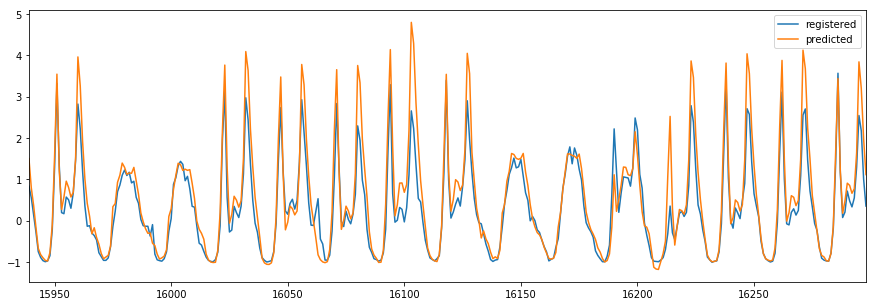

```python
results = pd.DataFrame(y_test)
results['predicted'] = y_pred.detach().numpy()

fig, ax = plt.subplots(figsize=(15,5))
results[:15*24].plot(ax=ax)
```

### Visualização dos 60 dias (do Conjunto de Teste)

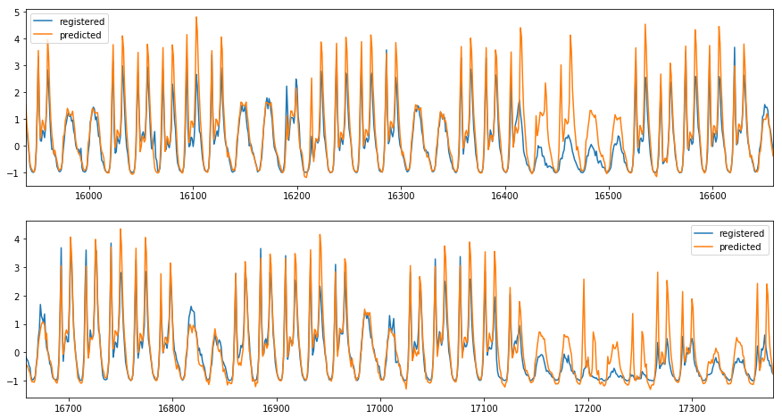

```python
fig, (ax1, ax2) = plt.subplots(2,1,figsize=(15,8))
results[:30*24].plot(ax=ax1)
results[-30*24:].plot(ax=ax2)
```

### Aumentando o Número de Épocas e Diminuindo a Taxa de Aprendizado

```python
from torch import optim
from torch.utils.data import DataLoader

lr = 0.01
batch_size = 64
num_epochs = 1000

model = Network_BikeSharing_1()
criterion = nn.MSELoss()
optimizer = optim.SGD(model.parameters(), lr=lr)

loader_train = DataLoader(train, batch_size=batch_size)
loader_test  = DataLoader(test , batch_size=batch_size)
```

Treinamento da rede neural e visualização de Loss durante o treinamento.

```python
import sys

train_losses = []
test_losses = []

for e in range(num_epochs):
    train_loss =  train_epoch(model, loader_train, optimizer, criterion)
    train_losses += [train_loss]

    test_loss  = eval_model(model, loader_test)
    test_losses += [test_loss]

    sys.stdout.write("\rProgress: {:2.1f}".format(100.0 * (e+1) / num_epochs) \
                     + "% ... Training loss: " + str(train_loss)[:5] \
                     + " ... Testing loss: " + str(test_loss)[:5] )
    sys.stdout.flush()
```

```
Progress: 100.0% ... Training loss: 0.052 ... Testing loss: 0.263
```

### Training Loss vs. Test Loss - Overfitting

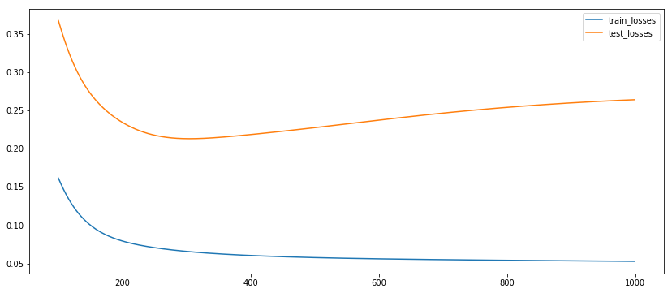

```python
fig, ax = plt.subplots(figsize=(14,6))
x = np.arange(100,1000)
ax.plot(x,train_losses[-900:], label='train_losses')
ax.plot(x,test_losses[-900:] , label='test_losses')
ax.legend()
```

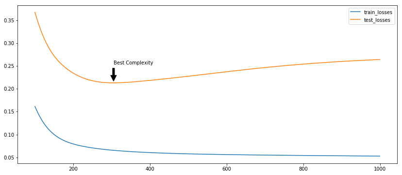

```python
fig, ax = plt.subplots(figsize=(14,6))
ax.plot(x,train_losses[-900:], label='train_losses')
ax.plot(x,test_losses[-900:] , label='test_losses')
argmin = np.argmin(test_losses)
ax.annotate('Best Complexity', xy=( argmin , test_losses[argmin]),
                   xytext=(argmin, test_losses[argmin]+0.04),
            arrowprops=dict(facecolor='black', shrink=0.1) )
ax.legend()
```

### Treinanndo Aumentando o Número de Épocas e Diminuindo a Taxa de Aprendizado

```python
from torch import optim
from torch.utils.data import DataLoader

lr = 0.01
batch_size = 64
num_epochs = 1000

model = Network_BikeSharing_1()
criterion = nn.MSELoss()
optimizer = optim.SGD(model.parameters(), lr=lr)

loader_train = DataLoader(train, batch_size=batch_size)
loader_test  = DataLoader(test , batch_size=batch_size)
```

Treinamento da rede neural e visualização de Loss durante o treinamento.

```python
import sys

train_losses = []
test_losses = []
best_test_loss = 10;


for e in range(num_epochs):
    train_loss =  train_epoch(model, loader_train, optimizer, criterion)
    train_losses += [train_loss]

    test_loss  = eval_model(model, loader_test)
    test_losses += [test_loss]

    if (test_loss < best_test_loss):
        best_test_loss = test_loss
        checkpoint = {
            'model': Network_BikeSharing_1(),
            'state_dict': model.state_dict(),
            'optimizer' : optimizer.state_dict(),
            'epoch': e
        }
        torch.save(checkpoint, 'checkpoint.pth')

    sys.stdout.write("\rProgress: {:2.1f}".format(100.0 * (e+1) / num_epochs) \
                     + "% ... Training loss: " + str(train_loss)[:5] \
                     + " ... Testing loss: " + str(test_loss)[:5] )
    sys.stdout.flush()
```

```
Progress: 0.1% ... Training loss: 0.879 ... Testing loss: 1.511
```

```
Progress: 100.0% ... Training loss: 0.053 ... Testing loss: 0.272
```

## Loss do Último Modelo Construído

```python
eval_model(model, loader_test)
```

```
0.2722998894751072
```

## Carregando o Melhor Modelo

```python
best_params = torch.load('checkpoint.pth')
best_params
```

```
{'model': Network_BikeSharing_1(
   (fc1): Linear(in_features=56, out_features=20, bias=True)
   (fc2): Linear(in_features=20, out_features=1, bias=True)
 ),
 'state_dict': OrderedDict([('fc1.weight',
               tensor([[-0.0329, -0.0202, -0.0988,  ..., -0.0754,  0.0362,  0.1710],
                       [-0.0713,  0.1278,  0.3424,  ..., -0.0112,  0.0441, -0.0427],
                       [-0.1113,  0.0939,  0.7679,  ...,  0.0718, -0.0822, -0.1393],
                       ...,
                       [ 0.1087,  0.0502,  0.2325,  ...,  0.0233, -0.0808, -0.0487],
                       [-0.2177,  0.0354, -0.0925,  ...,  0.1242,  0.1039, -0.0617],
                       [ 0.1987, -0.0946,  0.0788,  ..., -0.0729,  0.0025, -0.0645]])),
              ('fc1.bias',
               tensor([ 0.3973, -0.2837, -0.1782,  0.0905, -1.4960, -0.6436, -0.5167, -0.1518,
                        0.0622,  0.0178, -2.3793, -1.4725,  0.9862, -0.3076,  0.1972, -0.7043,
                       -0.0592, -0.2336, -0.0362,  0.0047])),
              ('fc2.weight',
               tensor([[ 0.6193,  0.6752,  0.6580, -0.0289,  2.1239, -0.9802,  0.9387,  0.0812,
                        -0.0743, -0.5534,  6.3233, -2.1125, -1.3394, -0.6363,  0.4877,  1.1217,
                        -0.4368, -0.4447,  0.6258, -0.3723]])),
              ('fc2.bias', tensor([-0.2038]))]),
 'optimizer': {'state': {},
  'param_groups': [{'lr': 0.01,
    'momentum': 0,
    'dampening': 0,
    'weight_decay': 0,
    'nesterov': False,
    'params': [2189263943648, 2189263943864, 2189263943072, 2189193053168]}]},
 'epoch': 349}
```

```python
best_model = best_params['model']
best_model.load_state_dict(best_params['state_dict'])
```

## Loss do Melhor Modelo Construído

```python
eval_model(best_model, loader_test)
```

```
0.22522856473274852
```

# Atividade

- Construir um modelo de regressão para as outras variáveis objetivo:
  - `casual`
  - `cnt`
- Pesquisar sobre redes neurais LSTM (Long Short Term Memory) e como usá-las em PyTorch.